# Covid-19 Vaccination Outcomes in Chicago

Christopher Whidden

2024-03-05

## Data

The data catalogued at data.gov and published and hosted by the city of Chicago. A link to the data can be found at https://data.cityofchicago.org/api/views/6irb-gasv/rows.csv?accessType=DOWNLOAD

```r
covid <- read_csv('https://data.cityofchicago.org/api/views/6irb-gasv/rows.csv?accessType=DOWNLOAD')
covid$Outcome <- as.factor(covid$Outcome)
covid$`Week End` <- mdy(covid$`Week End`)
covid$`Age Group` <- as.factor(covid$`Age Group`)
summary(covid)
```

```
##              Outcome        Week End            Age Group    Unvaccinated Rate
##  Cases           :1260   Min.   :2021-04-03   0-4    : 417   Min.   :   0.00
##  Deaths          :1242   1st Qu.:2021-11-27   12-17  : 417   1st Qu.:   0.00
##  Hospitalizations:1251   Median :2022-07-30   18-29  : 417   Median :   9.10
##                          Mean   :2022-07-30   30-49  : 417   Mean   :  72.43
##                          3rd Qu.:2023-04-01   5-11   : 417   3rd Qu.:  64.00
##                          Max.   :2023-12-02   50-64  : 417   Max.   :3690.90
##                                               (Other):1251
##  Vaccinated Rate    Boosted Rate     Crude Vaccinated Ratio Crude Boosted Ratio
##  Min.   :   0.00   Min.   :   0.00   Min.   :  0.000        Min.   : 0.000
##  1st Qu.:   0.00   1st Qu.:   0.00   1st Qu.:  1.300        1st Qu.: 1.000
##  Median :   2.50   Median :   4.00   Median :  2.300        Median : 1.600
##  Mean   :  42.44   Mean   :  48.65   Mean   :  4.547        Mean   : 2.952
##  3rd Qu.:  29.98   3rd Qu.:  42.50   3rd Qu.:  4.400        3rd Qu.: 3.200
##  Max.   :2009.50   Max.   :1520.30   Max.   :152.200        Max.   :73.000
##  NA's   :327       NA's   :1224      NA's   :1433           NA's   :1992
##  Age-Adjusted Unvaccinated Rate Age-Adjusted Vaccinated Rate
##  Min.   :   0.00                Min.   :   0.00
##  1st Qu.:   2.20                1st Qu.:   0.50
##  Median :  12.90                Median :   4.00
##  Mean   :  80.74                Mean   :  37.66
##  3rd Qu.:  71.40                3rd Qu.:  25.50
##  Max.   :2749.00                Max.   :1671.10
##  NA's   :3336                   NA's   :3336
##  Age-Adjusted Boosted Rate Age-Adjusted Vaccinated Ratio
##  Min.   :  0.00            Min.   : 0.000
##  1st Qu.:  0.30            1st Qu.: 1.700
##  Median :  4.60            Median : 2.200
##  Mean   : 43.83            Mean   : 4.712
##  3rd Qu.: 33.62            3rd Qu.: 3.900
##  Max.   :996.10            Max.   :61.200
##  NA's   :3423              NA's   :3373
##  Age-Adjusted Boosted Ratio Population Unvaccinated Population Vaccinated
##  Min.   : 0.000             Min.   :  23883         Min.   :      1
##  1st Qu.: 1.500             1st Qu.:  39417         1st Qu.:  73634
##  Median : 2.050             Median :  91824         Median : 125723
##  Mean   : 4.070             Mean   : 167070         Mean   : 251187
##  3rd Qu.: 3.025             3rd Qu.: 162642         3rd Qu.: 278401
##  Max.   :89.900             Max.   :1827674         Max.   :1519169
##  NA's   :3441                                       NA's   :540
##  Population Boosted Outcome Unvaccinated Outcome Vaccinated Outcome Boosted
##  Min.   :    411    Min.   :    0        Min.   :    0.00   Min.   :   0.0
##  1st Qu.:  44590    1st Qu.:    0        1st Qu.:    0.00   1st Qu.:   0.0
##  Median : 161682    Median :    8        Median :    4.00   Median :   5.0
##  Mean   : 242784    Mean   :  122        Mean   :   98.72   Mean   : 112.3
##  3rd Qu.: 246950    3rd Qu.:   57        3rd Qu.:   29.00   3rd Qu.:  47.0
##  Max.   :1049342    Max.   :19471        Max.   :20268.00   Max.   :7294.0
##  NA's   :1224                            NA's   :327        NA's   :1224
##  Age Group Min   Age Group Max
##  Min.   :  0.0   Min.   :  4.0
##  1st Qu.: 12.0   1st Qu.: 17.0
##  Median : 30.0   Median : 49.0
##  Mean   :139.9   Mean   :161.3
##  3rd Qu.: 65.0   3rd Qu.: 79.0
##  Max.   :999.0   Max.   :999.0
##
```

## EDA

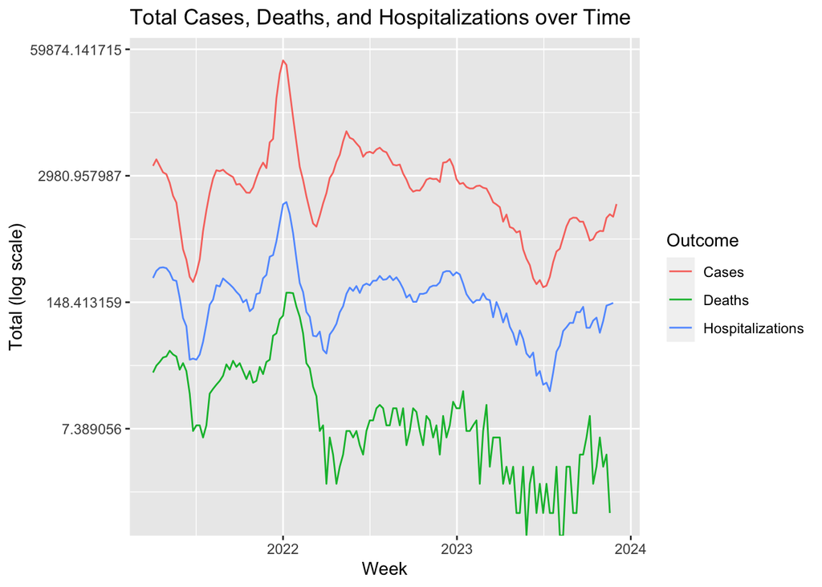

```r
covid %>%
  filter(`Age Group` == 'All') %>%
  mutate(Total = coalesce(`Outcome Unvaccinated`,0) + coalesce(`Outcome Vaccinated`,0) + coalesce(`Outcome Boosted`,0)) %>%
  select(Outcome, `Week End`, Total) %>%
  ggplot() +
  geom_line(aes(x=`Week End`, y=Total, col=Outcome)) +
  scale_y_continuous(trans = "log") +
  labs(x='Week',
       y='Total (log scale)',
       title='Total Cases, Deaths, and Hospitalizations over Time')
```

Vaccinations grew signficantly in 2021, and by the end of 2021, the rate of boosted population also rapidly grew.

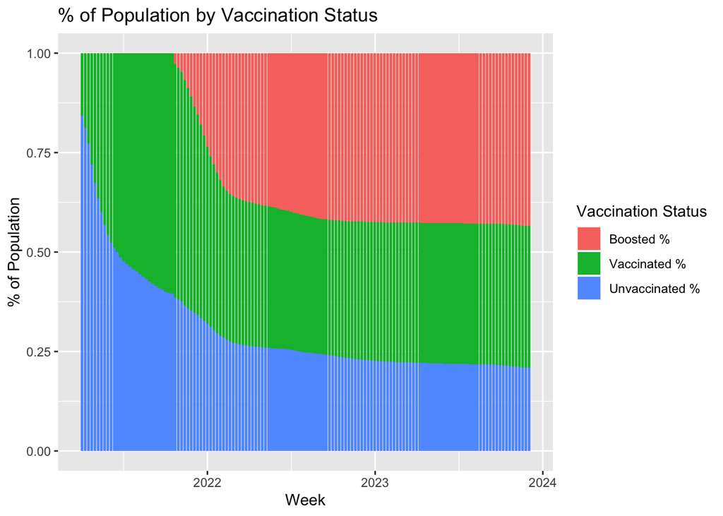

```r
covid %>%
  filter(`Age Group` == 'All', `Outcome` == 'Cases') %>%
  mutate(`Total Population` = coalesce(`Population Unvaccinated`,0) + coalesce(`Population Vaccinated`,0) + coalesce(`Population Boosted`,0)) %>%
  mutate(`Unvaccinated %` = `Population Unvaccinated` / `Total Population`,
         `Vaccinated %` = `Population Vaccinated` / `Total Population`,
         `Boosted %` = `Population Boosted` / `Total Population`) %>%
  select(`Week End`, `Unvaccinated %`, `Vaccinated %`, `Boosted %`) %>%
  pivot_longer(cols=-c('Week End'),
               names_to="Vaccination Status",
               values_to="%") %>%
  ggplot() +
  geom_bar(aes(x=`Week End`, y=`%`, fill=factor(`Vaccination Status`, levels=c('Boosted %', 'Vaccinated %', 'Unvaccinated %'))),position='stack', stat='identity') +
  scale_fill_discrete(name='Vaccination Status', breaks=c('Boosted %', 'Vaccinated %', 'Unvaccinated %')) +
  labs(x='Week',
       y='% of Population',
       title='% of Population by Vaccination Status')
```

## Models

```r
dataset <- covid %>%
  filter(`Age Group` == 'All') %>%
  mutate(`Total Population` = coalesce(`Population Unvaccinated`,0) + coalesce(`Population Vaccinated`,0) + coalesce(`Population Boosted`,0)) %>%
  mutate(Total = coalesce(`Outcome Unvaccinated`,0) + coalesce(`Outcome Vaccinated`,0) + coalesce(`Outcome Boosted`,0)) %>%
  mutate(`Vaccinated %` = coalesce(`Population Vaccinated`,0) / `Total Population`,
         `Boosted %` = coalesce(`Population Boosted`,0) / `Total Population`) %>%
  select(`Week End`, `Outcome`, `Total`, `Total Population`, `Vaccinated %`, `Boosted %`) %>%
  pivot_wider(names_from = 'Outcome',
              values_from = 'Total') %>%
  arrange(`Week End`) %>%
  mutate(lag1_Cases = lag(Cases, 1),
         lag2_Cases = lag(Cases, 2),
         lag3_Cases = lag(Cases, 3),
         lag4_Cases = lag(Cases, 4),
         lag5_Cases = lag(Cases, 5),
         lag6_Cases = lag(Cases, 6),
         lag7_Cases = lag(Cases, 7),
         lag8_Cases = lag(Cases, 8),
         lag1_Hospitalizations = lag(Hospitalizations, 1),
         lag2_Hospitalizations = lag(Hospitalizations, 2),
         lag3_Hospitalizations = lag(Hospitalizations, 3),
         lag4_Hospitalizations = lag(Hospitalizations, 4),
         lag5_Hospitalizations = lag(Hospitalizations, 5),
         lag6_Hospitalizations = lag(Hospitalizations, 6),
         lag7_Hospitalizations = lag(Hospitalizations, 7),
         lag8_Hospitalizations = lag(Hospitalizations, 8),
         lag1_Deaths = lag(Deaths, 1),
         lag2_Deaths = lag(Deaths, 2),
         lag3_Deaths = lag(Deaths, 3),
         lag4_Deaths = lag(Deaths, 4),
         lag5_Deaths = lag(Deaths, 5),
         lag6_Deaths = lag(Deaths, 6),
         lag7_Deaths = lag(Deaths, 7),
         lag8_Deaths = lag(Deaths, 8),
         roll4Deaths = (coalesce(lead(Deaths,1),0) + coalesce(lead(Deaths, 2),0) + coalesce(lead(Deaths, 3),0) + coalesce(lead(Deaths, 4),0))/4) %>%
  filter(row_number() <= n()-9) %>%
  filter(row_number() >= 9)

train <- dataset %>%
  filter(`Week End` < '2023-01-01')

model <- lm(roll4Deaths ~ . - `Week End`, data = train)
summary(model)
```

```
##
## Call:
## lm(formula = roll4Deaths ~ . - `Week End`, data = train)
##
## Residuals:
##      Min       1Q   Median       3Q      Max
## -11.7285  -3.8573  -0.8144   3.2945  18.3130
##
## Coefficients:
##                         Estimate Std. Error t value Pr(>|t|)
## (Intercept)            1.799e+02  1.856e+02   0.969 0.336713
## `Total Population`    -8.357e-05  8.147e-05  -1.026 0.309645
## `Vaccinated %`         6.566e+01  5.757e+01   1.140 0.259234
## `Boosted %`            2.496e+01  2.220e+01   1.125 0.265839
## Deaths                 1.022e+00  2.433e-01   4.198 0.000103 ***
## Hospitalizations       9.062e-02  3.469e-02   2.612 0.011676 *
## Cases                  2.298e-03  9.516e-04   2.415 0.019220 *
## lag1_Cases            -4.442e-03  1.466e-03  -3.030 0.003778 **
## lag2_Cases            -2.486e-03  1.544e-03  -1.610 0.113424
## lag3_Cases            -9.115e-04  1.757e-03  -0.519 0.606105
## lag4_Cases             5.313e-03  1.847e-03   2.877 0.005781 **
## lag5_Cases            -7.213e-04  2.001e-03  -0.360 0.719926
## lag6_Cases             1.773e-03  1.820e-03   0.975 0.334187
## lag7_Cases            -5.980e-04  1.750e-03  -0.342 0.733939
## lag8_Cases            -1.096e-03  1.306e-03  -0.839 0.405182
## lag1_Hospitalizations  3.644e-02  5.368e-02   0.679 0.500132
## lag2_Hospitalizations  3.356e-02  5.486e-02   0.612 0.543283
## lag3_Hospitalizations -7.739e-02  5.576e-02  -1.388 0.170997
## lag4_Hospitalizations -1.356e-01  5.106e-02  -2.655 0.010455 *
## lag5_Hospitalizations -3.348e-02  5.790e-02  -0.578 0.565515
## lag6_Hospitalizations  5.846e-02  5.435e-02   1.076 0.286955
## lag7_Hospitalizations -1.254e-02  5.463e-02  -0.230 0.819325
## lag8_Hospitalizations  1.808e-02  3.819e-02   0.473 0.637867
## lag1_Deaths            2.593e-01  2.850e-01   0.910 0.367058
## lag2_Deaths           -1.865e-01  2.787e-01  -0.669 0.506277
## lag3_Deaths            7.355e-02  2.421e-01   0.304 0.762443
## lag4_Deaths           -4.919e-02  2.413e-01  -0.204 0.839241
## lag5_Deaths           -5.874e-02  2.373e-01  -0.248 0.805410
## lag6_Deaths            8.092e-02  2.364e-01   0.342 0.733418
## lag7_Deaths            4.156e-02  2.009e-01   0.207 0.836881
## lag8_Deaths           -7.134e-02  1.373e-01  -0.520 0.605546
## ---
## Signif. codes:  0 '***' 0.001 '**' 0.01 '*' 0.05 '.' 0.1 ' ' 1
##
## Residual standard error: 7.683 on 53 degrees of freedom
## Multiple R-squared:  0.9732, Adjusted R-squared:  0.958
## F-statistic: 64.07 on 30 and 53 DF,  p-value: < 2.2e-16
```

```r
test <- dataset %>%
  filter(`Week End` >= '2023-01-01')

test$pred = predict(model, test)

rsme = sqrt(mean((test$roll4Deaths-test$pred)^2))
paste('rsme:', rsme, ', mean 4-day future death average:', mean(test$roll4Deaths))
```

```
## [1] "rsme: 9.38226189361396 , mean 4-day future death average: 3.60897435897436"
```

## Discussion

The results of the linear model show that future Covid deaths are difficult to predict from just the linear model alone. The linear model tends to overfit the data in this case, as can be seen from the high r-squared statistic from the training set, but root mean squared error on the test set is still quite high. Test prediction are also often negative, suggesting the simple linear model is not suitable for this dataset.